# Sensor data

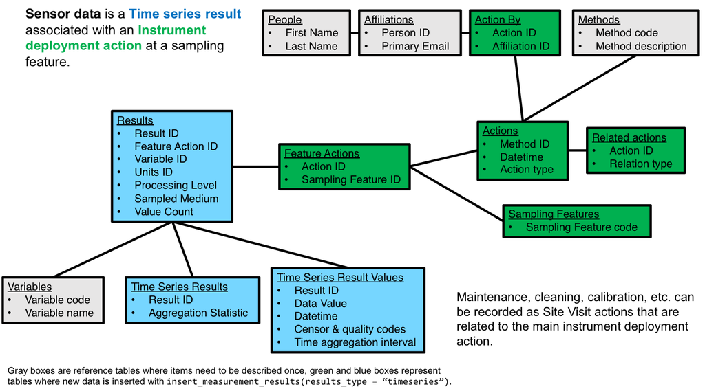

Connect to the database (as `db`) and load up the rodm2 package

```r
library(rodm2)
```

Before inserting a new type of measurements, it is necessary to first describe both the **methods** used to collect the data and the **variables** recorded.

**Database madlibs!**

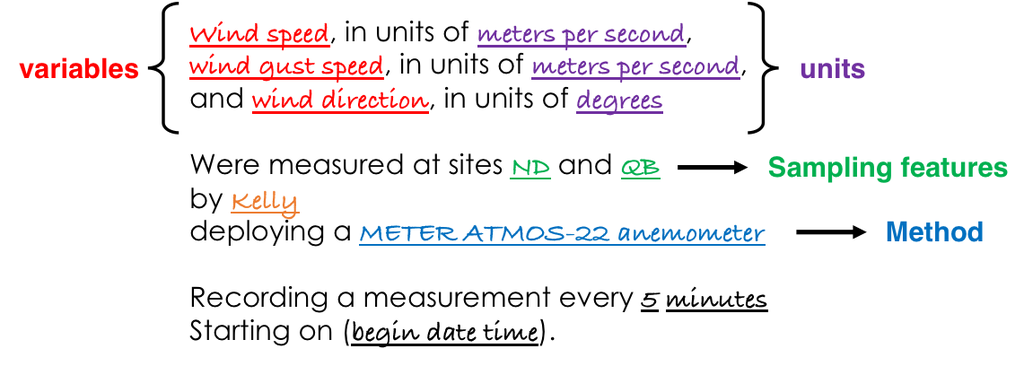

- Methods are described with a short code name, name, and description. They must be categorized using the method type vocabulary, in this case as “[Instrument deployment](http://vocabulary.odm2.org/methodtype/instrumentDeployment/)” methods.
- Variable names must come from [this list](http://vocabulary.odm2.org/variablename/) and be categorized using the [variable type vocabulary](http://vocabulary.odm2.org/variabletype/). A no data value (e.g. “-9999”) must also be supplied.
- In order to describe who collected this data, those people must be listed in the people and affiliations tables. Add new people (one at a time) with the function `db_describe_person()`.
- Actions and methods can also be linked to specific pieces of equipment using the [equipment tables](http://odm2.github.io/ODM2/schemas/ODM2_Current/diagrams/ODM2Equipment.html).

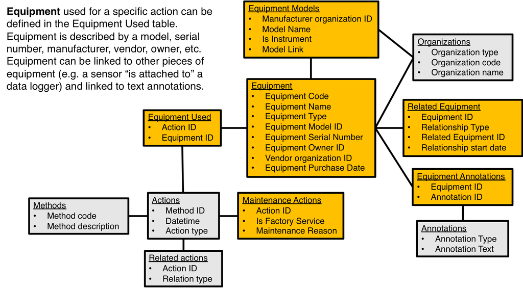

# Describe new methods

```r
db_describe_method(methodname = "Sonic anemometer deployment",
                   methodcode = "ATMOS22",
                   methodtypecv = "Instrument deployment",
                   methoddescription = "Continuous measurement of wind speed, direction, and gust speed using ATMOS-22 sonic anemometer.")
```

```
data frame with 0 columns and 0 rows
```

## Describe new variables

```r
db_describe_variable(variabletypecv = "Climate",
                     variablecode = "windGustSpeed",
                     variablenamecv = "Wind gust speed",
                     variabledefinition = "Speed of gusts of wind",
                     nodatavalue = "-9999")
```

```r
db_describe_variable(variabletypecv = "Climate",
                     variablecode = "windSpeed",
                     variablenamecv = "Wind speed",
                     variabledefinition = "Wind speed",
                     nodatavalue = "-9999")
```

```r
db_describe_variable(variabletypecv = "Climate",
                     variablecode = "windDirection",
                     variablenamecv = "Wind direction",
                     variabledefinition = "Wind direction",
                     nodatavalue = "-9999")
```

## Preparing Data Values

An input data frame should contain the results from a sensor deployed at one site. It needs a column for timestamps and a column for each variable. Information in each column of data is assumed to have the same:

- variable name
- units
- [processing level](https://github.com/ODM2/ODM2/blob/master/doc/ODM2Docs/core_processinglevels.md)
- sampled medium
- number of data values in the time series
- (optionally) a [status](http://vocabulary.odm2.org/status/)
- (optionally) a timestamp for when the result became available

The actual data (which goes into the [measurement result values](http://odm2.github.io/ODM2/schemas/ODM2_Current/tables/ODM2Results_TimeSeriesResultValues.html) table) is described by:

- data value
- timestamp
- timezone (as UTC offset)
- [censor code](http://vocabulary.odm2.org/censorcode/)
- [quality code](http://vocabulary.odm2.org/qualitycode/)
- time aggregation interval
- time aggregation interval units

For now, let’s assume that the censor code, quality code, and time aggregation interval do not vary throughout the time series, and that the processing level, sampled medium, and number of data values in the time series are equal if there are multiple variables collected in one instrument deployment (e.g. one sensor that records multiple values). Set those parameters here: